# Corporate Financial Resilience During COVID-19: Sweden vs Cayman Islands

# IDA

### Sample and coverage overview

```r
# Uses sweden_all already created above
yr_counts <- sweden_all |>
  dplyr::rename(firm_id = `BvD ID Number (os_id_number)`) |>
  dplyr::summarise(
    n_records   = dplyr::n(),
    n_companies = dplyr::n_distinct(firm_id),
    .by = year
  ) |>
  dplyr::arrange(year)

kableExtra::kbl(yr_counts, caption = "Records & unique companies by year") |>
  kableExtra::kable_styling(full_width = FALSE)
```

Records & unique companies by year

| year | n_records | n_companies |
| --- | --- | --- |
| 2017 | 825 | 818 |
| 2018 | 874 | 868 |
| 2019 | 933 | 926 |
| 2020 | 924 | 915 |
| 2021 | 911 | 910 |

```r
# Prefer sector_name, fall back to naics_sector
sector_col <- dplyr::case_when(
  "sector_name"  %in% names(sweden_all) ~ "sector_name",
  "naics_sector" %in% names(sweden_all) ~ "naics_sector",
  TRUE ~ NA_character_
)
stopifnot(!is.na(sector_col))

yr_sector_counts <- sweden_all |>
  dplyr::rename(firm_id = `BvD ID Number (os_id_number)`) |>
  dplyr::mutate(sector = tidyr::replace_na(.data[[sector_col]], "Unknown")) |>
  dplyr::summarise(
    n_records   = dplyr::n(),
    n_companies = dplyr::n_distinct(firm_id),
    .by = c(year, sector)
  ) |>
  dplyr::arrange(year, dplyr::desc(n_records))

yr_sector_distinct_counts <- yr_sector_counts  |>
  select(-n_records) |>
  pivot_wider(names_from = year,
              values_from = n_companies)

kableExtra::kbl(yr_sector_distinct_counts, caption = "Records & unique companies by year × sector") |>
  kableExtra::kable_styling(full_width = FALSE)
```

Records & unique companies by year × sector

| sector | 2017 | 2018 | 2019 | 2020 | 2021 |
| --- | --- | --- | --- | --- | --- |
| Manufacturing | 353 | 367 | 380 | 378 | 377 |
| Professional, Scientific & Technical Services | 85 | 89 | 89 | 86 | 86 |
| Wholesale Trade | 61 | 67 | 74 | 74 | 71 |
| Real Estate & Rental | 55 | 63 | 64 | 64 | 57 |
| Information | 45 | 45 | 47 | 44 | 44 |
| Administrative & Support | 30 | 34 | 38 | 39 | 38 |
| Mining, Quarrying, Oil & Gas Extraction | 26 | 25 | 24 | 22 | 23 |
| Finance & Insurance | 23 | 25 | 36 | 39 | 42 |
| Health Care & Social Assistance | 23 | 23 | 27 | 28 | 28 |
| Retail Trade | 22 | 29 | 35 | 31 | 36 |
| Construction | 19 | 18 | 20 | 18 | 18 |
| Arts, Entertainment & Recreation | 16 | 17 | 19 | 20 | 17 |
| Utilities | 16 | 18 | 22 | 22 | 25 |
| Transportation & Warehousing | 10 | 11 | 11 | 10 | 9 |
| Unknown | 8 | 9 | 9 | 10 | 10 |
| Other Services | 8 | 9 | 11 | 10 | 9 |
| Accommodation & Food Services | 5 | 5 | 4 | 3 | 3 |
| Education Services | 5 | 5 | 6 | 6 | 5 |
| Public Administration | 5 | 6 | 7 | 8 | 10 |
| Agriculture, Forestry, Fishing & Hunting | 3 | 3 | 3 | 3 | 2 |

Every year, manufacturing (about 380 businesses) dominates the sample, followed by professional, scientific and technical services, wholesale trade, real estate and rental, and information. Throughout, pandemic-sensitive industries like lodging and food services continue to hold a relatively tiny percentage.

From 2017 to 2021, the sector composition remained surprisingly consistent. Would be ideal to use of sector-stratified views thereafter to avoid the effects of big manufacturing numbers masking smaller sector changes.

#### Choosing a few important variables to start with. these are subjective. The analysis flow is taken from week 3 slides.

```r
# IDA: Sweden financial data

# Select relevant variables
key_vars <- c("Total Assets (data13077)",
              "Total Liabilities and Debt (data14022)",
              "Total revenues (data13004)",
              "Gross sales (data13000)",
              "Earnings before tax (data13034)",
              "Earnings after tax (data13037)",
              "Profit Margin (%) (data31005)",
              "No. Of employed (data23000)",
              "naics_sector",
              "sector_name",
              "year")

sweden_ida <- sweden_all %>% select(any_of(key_vars))

# 1. Structure & types

# 2. Numeric summary
summary(sweden_ida)
```

```
 Total Assets (data13077)
 Min.   :0.00e+00
 1st Qu.:3.91e+04
 Median :1.85e+05
 Mean   :8.12e+06
 3rd Qu.:1.51e+06
 Max.   :7.96e+08
 NA's   :1
 Total Liabilities and Debt (data14022)
 Min.   :0.00e+00
 1st Qu.:1.01e+04
 Median :6.09e+04
 Mean   :4.49e+06
 3rd Qu.:7.30e+05
 Max.   :5.85e+08
 NA's   :1
 Total revenues (data13004) Gross sales (data13000)
 Min.   :    -3556          Min.   :    -3556
 1st Qu.:     6794          1st Qu.:     5853
 Median :    83294          Median :    84041
 Mean   :  4776653          Mean   :  4799922
 3rd Qu.:  1009757          3rd Qu.:  1012044
 Max.   :432663000          Max.   :431980000
 NA's   :37                 NA's   :90
 Earnings before tax (data13034)
 Min.   :-35958000
 1st Qu.:   -16025
 Median :    -1258
 Mean   :   623104
 3rd Qu.:    92344
 Max.   :228322000
 NA's   :3
 Earnings after tax (data13037)
 Min.   :-32433000
 1st Qu.:   -15790
 Median :    -1400
 Mean   :   513087
 3rd Qu.:    75507
 Max.   :227965000
 NA's   :1
 Profit Margin (%) (data31005) No. Of employed (data23000)
 Min.   :-100                  Min.   :     1
 1st Qu.:  -9                  1st Qu.:    11
 Median :   4                  Median :    45
 Mean   :  -2                  Mean   :  2438
 3rd Qu.:  11                  3rd Qu.:   420
 Max.   : 100                  Max.   :302055
 NA's   :1598                  NA's   :280
 naics_sector       sector_name             year
 Length:4467        Length:4467        Min.   :2017
 Class :character   Class :character   1st Qu.:2018
 Mode  :character   Mode  :character   Median :2019
                                       Mean   :2019
                                       3rd Qu.:2020
                                       Max.   :2021
```

```r
# 3. Missingness
round(colMeans(is.na(sweden_ida))*100, 1)
```

```
              Total Assets (data13077)
                                   0.0
Total Liabilities and Debt (data14022)
                                   0.0
            Total revenues (data13004)
                                   0.8
               Gross sales (data13000)
                                   2.0
       Earnings before tax (data13034)
                                   0.1
        Earnings after tax (data13037)
                                   0.0
         Profit Margin (%) (data31005)
                                  35.8
           No. Of employed (data23000)
                                   6.3
                          naics_sector
                                   1.0
                           sector_name
                                   1.0
                                  year
                                   0.0
```

```r
# 4. Plausibility checks
range(sweden_ida$`Profit Margin (%) (data31005)`, na.rm = TRUE)
```

```
[1] -100  100
```

**Simplifying variables names**

```r
# --- Rename core variables for clarity
sweden_ida_sub <- sweden_ida %>%
  rename(
    total_assets       = `Total Assets (data13077)`,
    total_liabilities  = `Total Liabilities and Debt (data14022)`,
    total_revenues     = `Total revenues (data13004)`,
    gross_sales        = `Gross sales (data13000)`,
    earnings_before_tax= `Earnings before tax (data13034)`,
    earnings_after_tax = `Earnings after tax (data13037)`,
    profit_margin      = `Profit Margin (%) (data31005)`,
    employees          = `No. Of employed (data23000)`
  )
```

#### Patterns within total assets and liabilities and debt

Here, some basic investigation into the patterns within the total assets and liabilities is done. First, a simple histogram to see the distribution of assets and liabilities in a single year to get an idea of the distribution.

```r
# initial investigation will not use a tsibble, only looking at means across all observations in the 5 years
sweden_al_sub <- sweden_ida_sub %>%
      select(year, total_assets, total_liabilities, sector_name) %>%
          mutate(l_assets = log10(total_assets + 1),
                 l_liab = log10(total_liabilities+ 1))
# incorporated log statistics based on below observations for easier readability
```

Separating the data, we now do a simple plot to see if there’s anything obvious, doing a simple histogram (Lecture 1, slide 34).

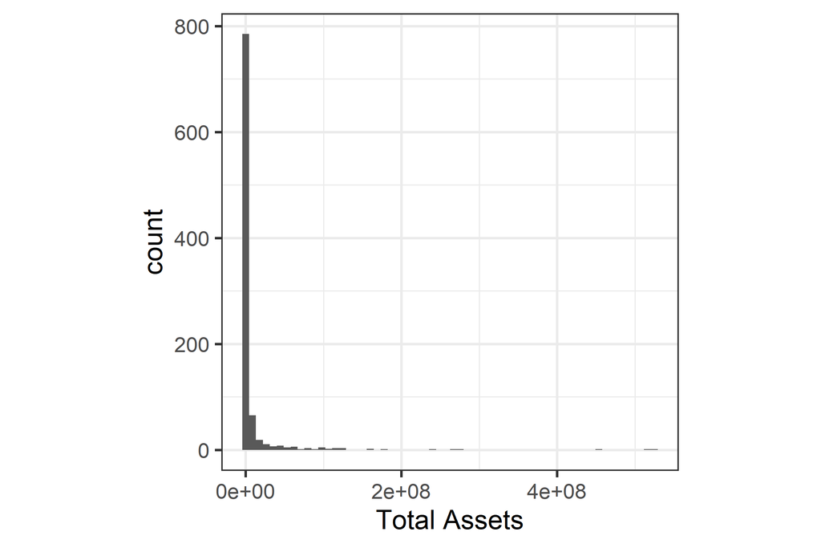

```r
# first look at one year to see the distribution
sweden_al_sub %>% filter(year == 2019) %>%
  ggplot(aes(x = total_assets)) +
  geom_histogram(bins = 60) +
  labs(x = "Total Assets")
```

We can see severe right skewness (which makes sense for financial data), so we will apply a log scale (Lecture 5, slide 28) to make the plot easier to understand and visualise.

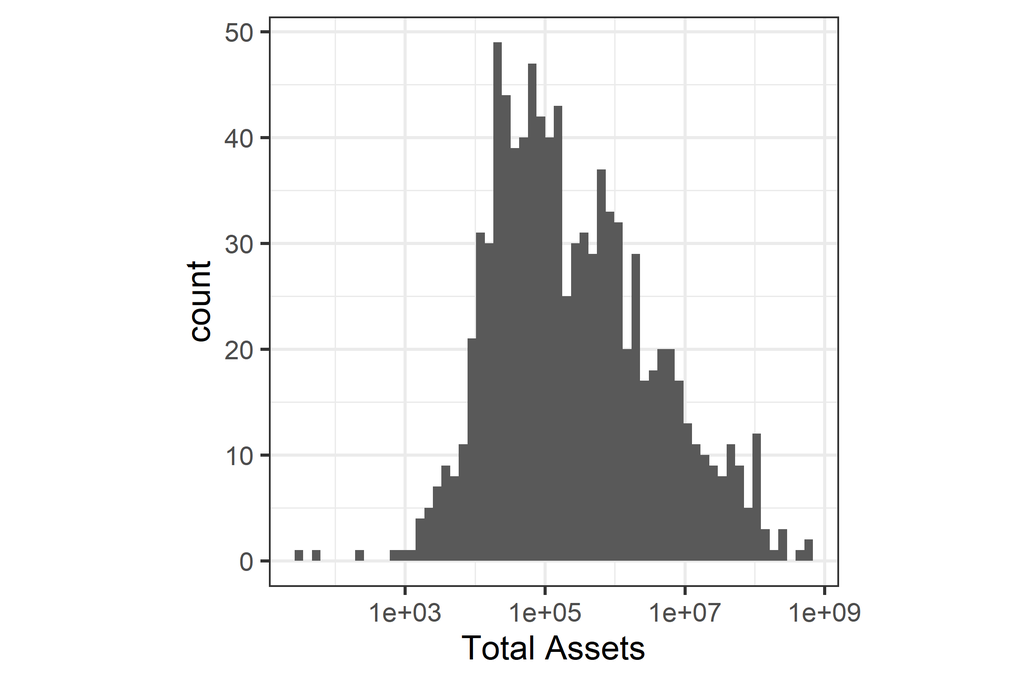

```r
# first look at one year to see the distribution
sweden_al_sub %>% filter(year == 2019) %>%
  ggplot(aes(x = total_assets)) +
  geom_histogram(bins = 60) +
  scale_x_log10() +
  labs(x = "Total Assets")
```

# EDA (with some analysis between)

Looking at this plot, we see a better distribution of the data, where it is relatively normally distributed, so we can use this to generate our means and medians to get a better idea of the distributions (scaling with log and then transforming back) (Lecture 5, slide 29). We also need to add 1 when transforming with the log to ensure we don’t have negative infinity skewing our means. (This was moved a couple chunks up since this will be reused).

```r
sweden_al_summary <- sweden_al_sub  %>%
          group_by(year) %>%
          summarise(`Mean Assets` = 10^mean(l_assets, na.rm = TRUE) - 1,
                    `Median Assets` = 10^median(l_assets, na.rm = TRUE) - 1,
                    `Mean Liabilities` = 10^mean(l_liab, na.rm = TRUE) - 1,
                    `Median Liabilities` = 10^median(l_liab, na.rm = TRUE) - 1)
sweden_al_summary
```

```
# A tibble: 5 × 5
   year `Mean Assets` `Median Assets` `Mean Liabilities`
  <dbl>         <dbl>           <dbl>              <dbl>
1  2017       236607.         151625              79270.
2  2018       260469.         181090.             91422.
3  2019       254012.         167543              92274.
4  2020       300879.         185400              96810.
5  2021       387618.         268745.            117406.
# ℹ 1 more variable: `Median Liabilities` <dbl>
```

We see that there is a general increasing trend, although interestingly there appears to be a dip in 2019, although this may be a pattern of the collection methods. To get a better understanding of the distribution, we can use a boxplot to visualise this (Lecture 5, slide 17).

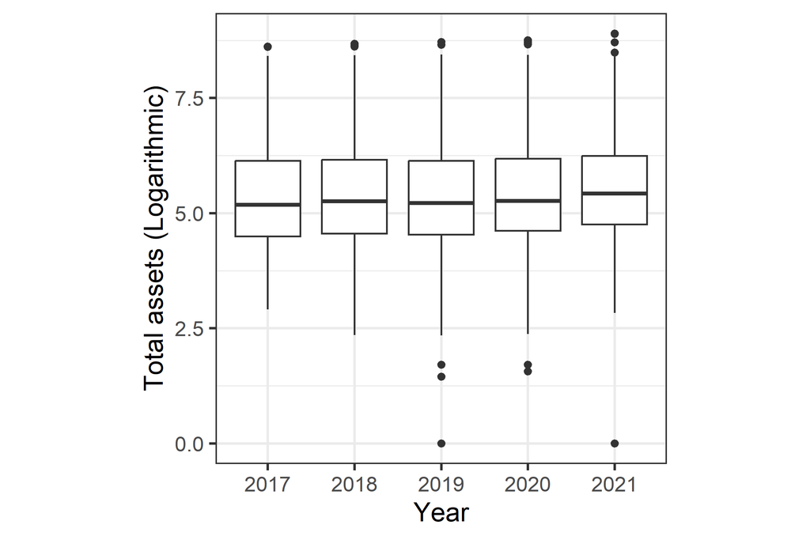

```r
sweden_al_sub %>%
  ggplot(aes(x = factor(year), y = l_assets)) +
  geom_boxplot() +
  labs(
    x = "Year",
    y = "Total assets (Logarithmic)"
  )
```

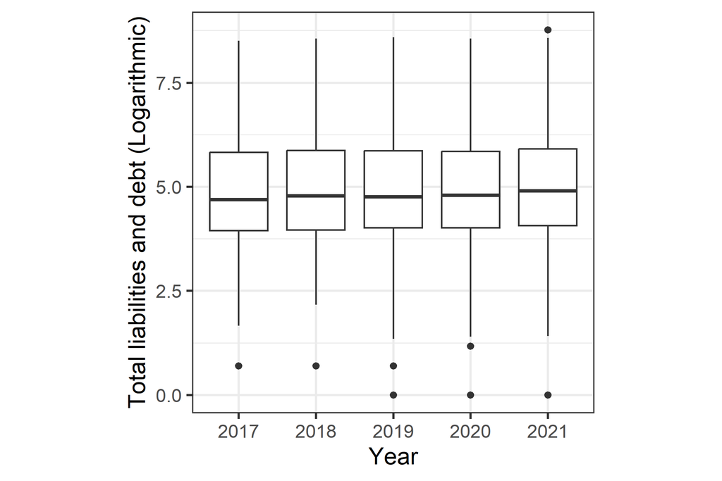

```r
sweden_al_sub %>%
  ggplot(aes(x = factor(year), y = l_liab)) +
  geom_boxplot() +
  labs(
    x = "Year",
    y = "Total liabilities and debt (Logarithmic)"
  )
```

To get a better idea of underlying patterns, we can do some stratified visualisation based on the sectors. (Lecture 6, Slide 19)

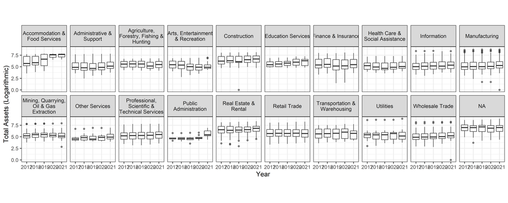

```r
sweden_al_sub %>%
  ggplot(aes(x = factor(year), y = l_assets)) +
  geom_boxplot(alpha = 0.6) +
  facet_wrap(~sector_name, ncol = 10, labeller = label_wrap_gen(width = 20)) +
  theme(aspect.ratio = 1) +
  labs(
    x = "Year",
    y = "Total Assets (Logarithmic)"
  )
```

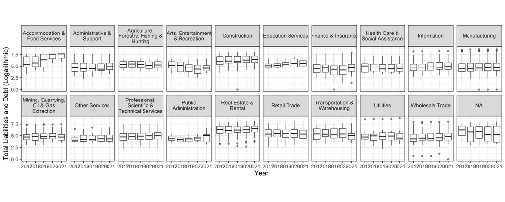

```r
sweden_al_sub %>%
  ggplot(aes(x = factor(year), y = l_liab)) +
  geom_boxplot(alpha = 0.6) +
  facet_wrap(~sector_name, ncol = 10, labeller = label_wrap_gen(width = 20)) +
  theme(aspect.ratio = 1) +
  labs(
    x = "Year",
    y = "Total Liabilities and Debt (Logarithmic)"
  )
```

Looking at this distribution across the different sectors, we can notice there are numerous more interesting changes across the years for many sectors. For example, there are significant spikes in pandemic years (2020 and 2021) in the Accommodation & Food Services and Public Administration. When comparing this to the number of companies across the years, the increase in total assets for Accommodation & Food Services is likely attributed to the poorer performing companies having to shutdown, and only high performing companies remaining. Conversely, the pattern shown in Public Administration is likely due to the relatively large increase in the number of companies in the sector in the pandemic years.

Looking at larger sectors, such as Manufacturing, and Professional, Scientific & Technical services, and Wholesale Trade, there are no significant shifts, although they do have slightly upward trends which aligns with previous inspections of general increases across each year, with no noticeable impact on the total assets or liabilities.

Sectors where this pattern noticeably differs is within the Arts, Entertainment & Recreation, likely due to overall reduced recreational usage, as well as minor drops within the Agriculture, Forestry, Fishing & Hunting and Transportation & Warehousing sectors, which may be attributed to limited outdoor access during pandemic control measures. We also see a noticeable shift in the median assets and liabilities of Education Services, perhaps a result of government or external investment in resources required for remote learning capabilities during the pandemic.

#### Earnings before & after tax

**Investigation into the patterns in earnings before tax and after tax is done below**

```r
ebt <- sweden_ida_sub %>%
  select(year,earnings_before_tax, earnings_after_tax)

#checking if major na values are present.

ebt %>%
  filter(is.na(earnings_after_tax)) %>%
  count()
```

```
# A tibble: 1 × 1
      n
  <int>
1     1
```

**doing a simple histogram to check distribution. from lecture 1**

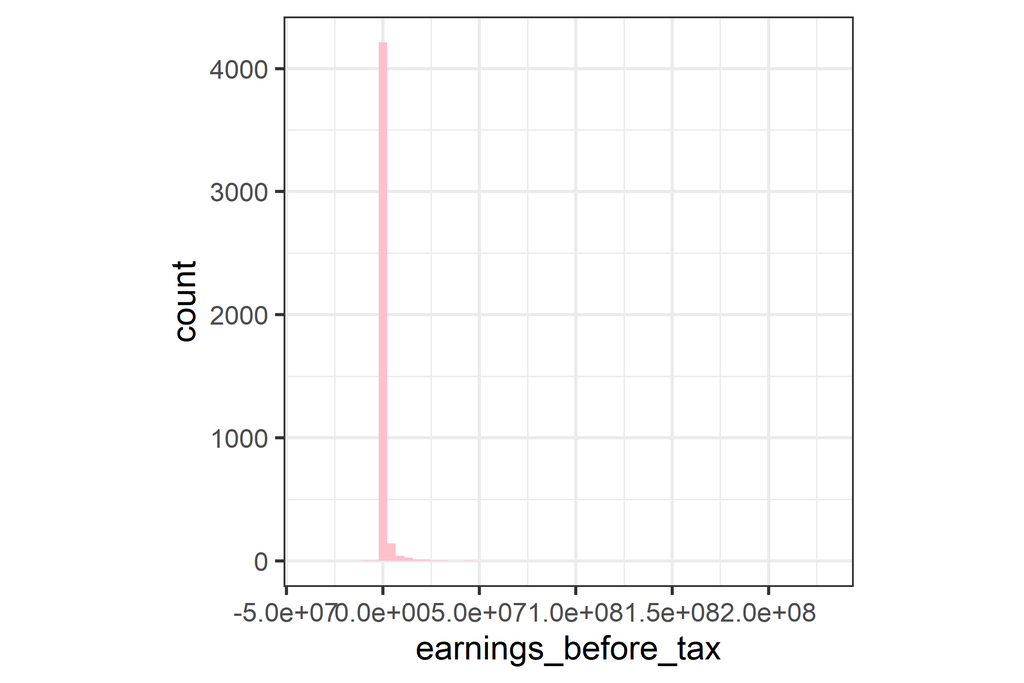

```r
ggplot(ebt, aes(x=earnings_before_tax))+
  geom_histogram(bins=60, fill="pink")
```

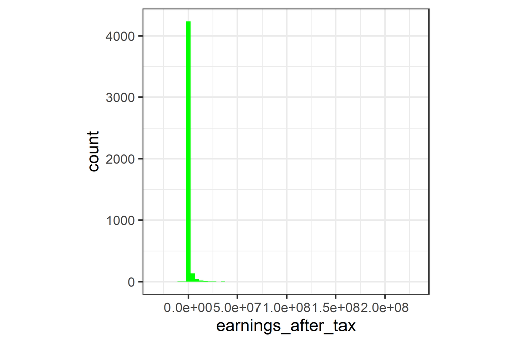

```r
ggplot(ebt, aes(x=earnings_after_tax))+
  geom_histogram(bins = 60, fill = "green")
```

```r
ebt %>%
  group_by(year) %>%
  summarise(
    min_value    = min(earnings_before_tax, na.rm = TRUE),
    median_value = median(earnings_before_tax, na.rm = TRUE),
    mean_value   = mean(earnings_before_tax, na.rm = TRUE),
    max_value    = max(earnings_before_tax, na.rm = TRUE)
  )
```

```
# A tibble: 5 × 5
   year min_value median_value mean_value max_value
  <dbl>     <dbl>        <dbl>      <dbl>     <dbl>
1  2017 -35958000        -886     529314.  44542000
2  2018 -13655000       -1432.    431816.  32148000
3  2019   -739920       -1331     675609. 102650000
4  2020 -21174000       -1198.    470808.  53125000
5  2021  -6525000       -1668.    993476. 228322000
```

Mean positive + median negative possible explains strong right skew. we can validate that with the visualisations done before. A few firms report very high profits.

**Log transforming the earnings to better visualise. (from week 5 slide 28)**

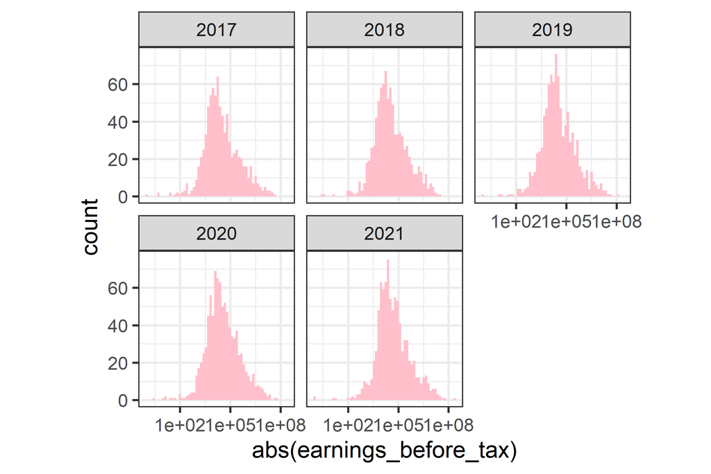

```r
ggplot(ebt, aes(x=abs(earnings_before_tax)))+
  geom_histogram(bins=60, fill="pink")+
  scale_x_log10()+
  facet_wrap(~year)
```

Creating the yearly summary for log(absolute earnings)

```r
ebt_year_summary <- ebt %>%
  mutate(log_abs_ebt = log10(abs(earnings_before_tax) + 1)) %>%  # add +1 to avoid log(0)
  group_by(year) %>%
  summarise(
    mean_log_ebt   = mean(log_abs_ebt, na.rm = TRUE),
    median_log_ebt = median(log_abs_ebt, na.rm = TRUE)
  )
ebt_year_summary
```

```
# A tibble: 5 × 3
   year mean_log_ebt median_log_ebt
  <dbl>        <dbl>          <dbl>
1  2017         4.49           4.32
2  2018         4.54           4.42
3  2019         4.53           4.41
4  2020         4.54           4.43
5  2021         4.70           4.58
```

To avoid dropping firms with negative earnings, we have used absolute values of earnings. This allows analysis of earnings magnitudes. the values given above are exponents to base 10.

The proportion of profit- and loss-making firms remained roughly constant over 2017–2021, suggesting no major structural shift in profitability. However, the log-transformed absolute earnings before tax increased sharply in 2021, indicating that the size of both profits and losses expanded. This pattern likely reflects a bit of volatility during the pandemic, where some firms experienced exceptional gains while others suffered larger losses.

#### Classify earnings in the direction of either profit or loss

```r
# 1) Tag direction using BEFORE-tax earnings
ebt_direction <- ebt %>%
  mutate(
    direction = case_when(
      earnings_before_tax > 0 ~ "Profit",
      earnings_before_tax < 0 ~ "Loss",
      TRUE ~ "Zero"
    )
  )
```

**Checking profit vs loss firms by year**

```r
# Table
ebt_direction %>%
  group_by(year, direction) %>%
  summarise(
    n_firms = n(),
    median_ebt = median(earnings_before_tax, na.rm = TRUE),
    mean_ebt   = mean(earnings_before_tax,   na.rm = TRUE),
    .groups = "drop"
  )
```

```
# A tibble: 14 × 5
    year direction n_firms median_ebt mean_ebt
   <dbl> <chr>       <int>      <dbl>    <dbl>
 1  2017 Loss          430    -10528. -111477.
 2  2017 Profit        395    105574  1226884.
 3  2018 Loss          458    -12938   -92853.
 4  2018 Profit        415    112097  1011889.
 5  2018 Zero            1         0        0
 6  2019 Loss          499    -15054   -37552.
 7  2019 Profit        433    108000  1499034.
 8  2019 Zero            1         0        0
 9  2020 Loss          481    -16400  -130447.
10  2020 Profit        441     87000  1128734.
11  2020 Zero            2         0        0
12  2021 Loss          471    -20763   -77026.
13  2021 Profit        437    126749  2147266.
14  2021 Zero            3        NA      NaN
```

**plotting it using barplots**

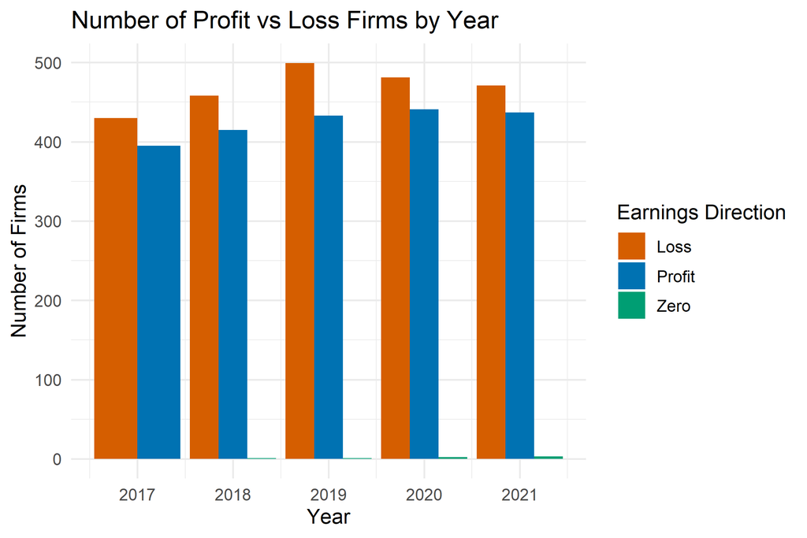

```r
# Plot (counts)
ebt_direction %>%
  group_by(year, direction) %>%
  summarise(n_firms = n(), .groups = "drop") %>%
  ggplot(aes(x = year, y = n_firms, fill = direction)) +
  geom_col(position = "dodge") +
  labs(
    title = "Number of Profit vs Loss Firms by Year",
    x = "Year", y = "Number of Firms", fill = "Earnings Direction"
  ) +
  theme_minimal()
```

Not much of a difference between numbers of profit and loss amking firms. the ratios remain balanced throughout the years.

Now, Using the existing earnings direction categories, we shall compare the median magnitudes of before and after-tax earnings on a log10 scale

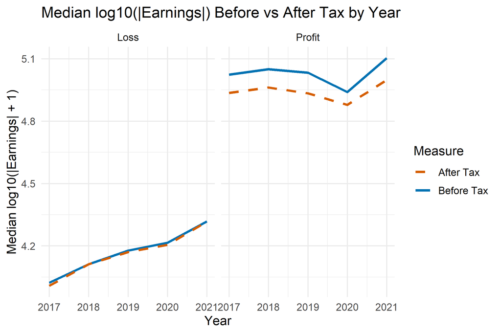

```r
# Add after-tax variables and log transforms
ebt_compare <- ebt_direction %>%
  mutate(
    log_abs_ebt = log10(abs(earnings_before_tax) + 1),
    log_abs_eat = log10(abs(earnings_after_tax)  + 1)
  )

# Summarise by year and direction
summary_simple <- ebt_compare %>%
  group_by(year, direction) %>%
  summarise(
    median_before = median(log_abs_ebt, na.rm = TRUE),
    median_after  = median(log_abs_eat, na.rm = TRUE),
    .groups = "drop"
  )

# Plot, excluding Zero direction
summary_simple %>%
  filter(direction %in% c("Profit", "Loss")) %>%
  ggplot(aes(x = year)) +
  geom_line(aes(y = median_before, color = "Before Tax", group = direction), linewidth = 1) +
  geom_line(aes(y = median_after,  color = "After Tax",  group = direction),
            linewidth = 1, linetype = "dashed") +
  facet_wrap(~ direction, nrow = 1) +
  labs(
    title = "Median log10(|Earnings|) Before vs After Tax by Year",
    x = "Year", y = "Median log10(|Earnings| + 1)",
    color = "Measure"
  ) +
  theme_minimal()
```

During COVID-19 some companies globally decided to downsize their workforce, then we can explore the number of employees as a proxy of financial health. However in the following summary, we observe that in a pre-pandemic period the average number of employees was lower than in the pandemic period. It is an interesting pattern that should be investigated, based on Lecture 3 slides (slide 46) we can run a t-test to do hypothesis testing.

```r
# initial investigation will not use a tsibble, only looking at means across all observations in the 5 years
sweden_small <- sweden_ida_sub %>%
      select(year, employees, profit_margin, naics_sector)

sweden_small <- sweden_small %>%
  mutate(pandemic_period = case_when(
    year < 2020 ~ 'pre-pandemic',
    year %in% c (2020, 2021, 2022) ~ 'pandemic',
    year >= 2023 ~ 'post-pandemic'
  ))

summary_by_period <- sweden_small %>%
  group_by(pandemic_period) %>%
  summarise(
    avg_profit_margin = mean(profit_margin, na.rm = TRUE),
    avg_employees = mean(employees, na.rm = TRUE),
    n_firms = n()
  )

summary_by_period
```

```
# A tibble: 2 × 4
  pandemic_period avg_profit_margin avg_employees n_firms
  <chr>                       <dbl>         <dbl>   <int>
1 pandemic                    -2.62         2450.    1835
2 pre-pandemic                -1.76         2431.    2632
```

```r
#week3 slide 46

tt <- with(sweden_small,
  t.test(
    employees[pandemic_period == "pre-pandemic"],
    employees[pandemic_period == "pandemic"],
    paired = FALSE
  )
)

tt
```

```
    Welch Two Sample t-test

data:  employees[pandemic_period == "pre-pandemic"] and employees[pandemic_period == "pandemic"]
t = -0.04, df = 3541, p-value = 1
alternative hypothesis: true difference in means is not equal to 0
95 percent confidence interval:
 -898  859
sample estimates:
mean of x mean of y
     2431      2450
```

Based on Week2, we produce scaled box-plots (y scale log 10) to compare the number of employees in the biggest sectors (21 = “Mining, Quarrying, Oil & Gas Extraction”, 32 and “33 =”Manufacturing”, 42 = “Wholesale Trade”, 51 = “Information”, 52 = “Finance & Insurance”, 53 = “Real Estate & Rental”, 54 = “Professional, Scientific & Technical Services”, 56 = “Administrative & Support, 62 =”Health Care & Social Assistance”).

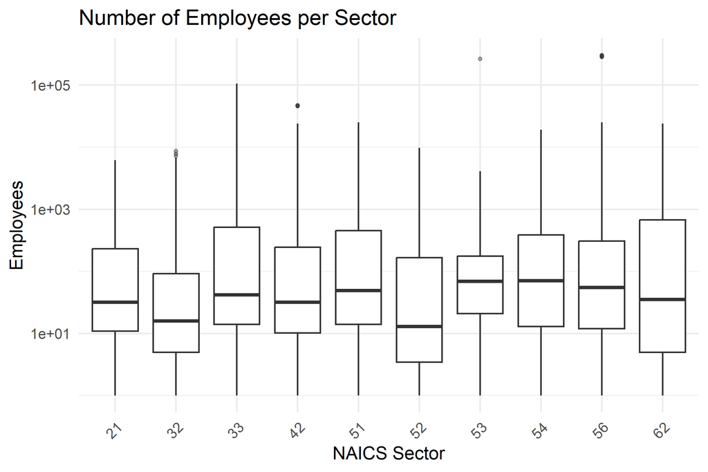

```r
sweden_plot <- sweden_small %>%
  filter(!is.na(employees), !is.na(naics_sector), !is.na(pandemic_period))

# Filter to sectors with at least 30 firms
top_sectors <- sweden_plot %>%
  group_by(naics_sector) %>%
  tally() %>%
  filter(n >= 100) %>%
  pull(naics_sector)

sweden_plot <- sweden_plot %>%
  filter(naics_sector %in% top_sectors)

ggplot(sweden_plot, aes(x = naics_sector, y = employees)) +
  geom_boxplot(outlier.size = 0.8, outlier.alpha = 0.4) +
  scale_y_log10()+
  labs(title = "Number of Employees per Sector",
       x = "NAICS Sector",
       y = "Employees") +
  theme_minimal() +
  theme(axis.text.x = element_text(angle = 45, hjust = 1))
```

Now we will look into the patterns between the two variables Total Revenues and Gross sales. Before commencing, we will. take a look at the data and create a quick profile for the 2 variables.

```r
# a small focus frame
vars_use <- sweden_all |>
  dplyr::select(
    year,
    total_revenues = `Total revenues (data13004)`,
    gross_sales    = `Gross sales (data13000)`
  ) |>
  mutate(
    total_revenues = as.numeric(total_revenues),
    gross_sales    = as.numeric(gross_sales)
  )

# an overall summary (types, missing, basic stats)
skimr::skim(vars_use[, c("total_revenues","gross_sales")])
```

Data summary

| Name | vars_use[, c(“total_reven… |
| --- | --- |
| Number of rows | 4467 |
| Number of columns | 2 |
| _______________________ |  |
| Column type frequency: |  |
| numeric | 2 |
| ________________________ |  |
| Group variables | None |

**Variable type: numeric**

| skim_variable | n_missing | complete_rate | mean | sd | p0 | p25 | p50 | p75 | p100 | hist |
| --- | --- | --- | --- | --- | --- | --- | --- | --- | --- | --- |
| total_revenues | 37 | 0.99 | 4776653 | 2.3e+07 | -3556 | 6794 | 83294 | 1e+06 | 4.3e+08 | ▇▁▁▁▁ |
| gross_sales | 90 | 0.98 | 4799922 | 2.3e+07 | -3556 | 5853 | 84041 | 1e+06 | 4.3e+08 | ▇▁▁▁▁ |

```r
# checking missingness by year
vars_use |>
  summarise(
    n = dplyr::n(),
    missing_total_revenues = sum(is.na(total_revenues)),
    missing_gross_sales    = sum(is.na(gross_sales)),
    .by = year
  ) |>
  arrange(year) |>
  kableExtra::kbl(caption = "Missingness by year: total_revenues & gross_sales") |>
  kableExtra::kable_styling(full_width = FALSE)
```

Missingness by year: total_revenues & gross_sales

| year | n | missing_total_revenues | missing_gross_sales |
| --- | --- | --- | --- |
| 2017 | 825 | 8 | 19 |
| 2018 | 874 | 6 | 14 |
| 2019 | 933 | 7 | 18 |
| 2020 | 924 | 8 | 17 |
| 2021 | 911 | 8 | 22 |

```r
# scale check medians & IQR by year (robust, handles heavy tails)
vars_use |>
  summarise(
    n = dplyr::n(),
    median_total_revenues = median(total_revenues, na.rm = TRUE),
    IQR_total_revenues    = IQR(total_revenues, na.rm = TRUE),
    median_gross_sales    = median(gross_sales, na.rm = TRUE),
    IQR_gross_sales       = IQR(gross_sales, na.rm = TRUE),
    .by = year
  ) |>
  arrange(year) |>
  kableExtra::kbl(caption = "Robust summaries by year (median & IQR)") |>
  kableExtra::kable_styling(full_width = FALSE)
```

Robust summaries by year (median & IQR)

| year | n | median_total_revenues | IQR_total_revenues | median_gross_sales | IQR_gross_sales |
| --- | --- | --- | --- | --- | --- |
| 2017 | 825 | 72619 | 1042427 | 73933 | 1060882 |
| 2018 | 874 | 81637 | 1095133 | 77946 | 1094583 |
| 2019 | 933 | 86115 | 998986 | 86900 | 1000553 |
| 2020 | 924 | 80739 | 899095 | 81083 | 887894 |
| 2021 | 911 | 96202 | 926047 | 96804 | 918679 |

```r
# zeros/negatives (checkin in case of potential log scales later)
vars_use |>
  summarise(
    zeros_total_revenues = sum(!is.na(total_revenues) & total_revenues == 0),
    negatives_total_revenues = sum(!is.na(total_revenues) & total_revenues < 0),
    zeros_gross_sales = sum(!is.na(gross_sales) & gross_sales == 0),
    negatives_gross_sales = sum(!is.na(gross_sales) & gross_sales < 0)
  ) |>
  kableExtra::kbl(caption = "Zero/negative counts") |>
  kableExtra::kable_styling(full_width = FALSE)
```

Zero/negative counts

| zeros_total_revenues | negatives_total_revenues | zeros_gross_sales | negatives_gross_sales |
| --- | --- | --- | --- |
| 154 | 2 | 333 | 2 |

Will look at yearly medians with IQR ribbons which uses dplyr + ggplot2; Week 2 & Week 5 content:

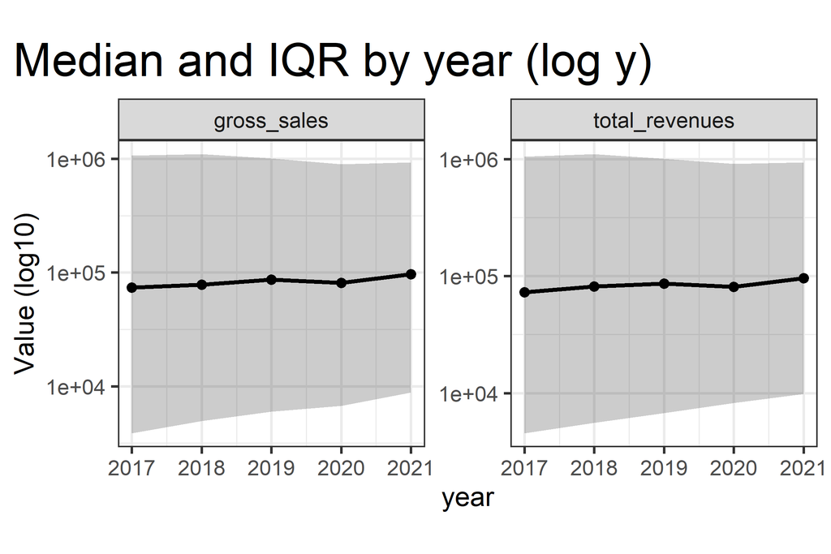

```r
q_by_year <- vars_use |>
  tidyr::pivot_longer(c(total_revenues, gross_sales),
                      names_to="metric", values_to="value") |>
  dplyr::summarise(
    n = dplyr::n(),
    q25 = quantile(value, .25, na.rm=TRUE),
    med = median(value, na.rm=TRUE),
    q75 = quantile(value, .75, na.rm=TRUE),
    .by = c(year, metric)
  )

ggplot(q_by_year, aes(x = year, y = med)) +
  geom_ribbon(aes(ymin = q25, ymax = q75), alpha = 0.25) +
  geom_line(linewidth = 1) + geom_point(size = 2) +
  scale_y_log10() +
  facet_wrap(~ metric, scales = "free_y") +
  labs(title = "Median and IQR by year (log y)",
       y = "Value (log10)")
```

For both gross_sales and total_revenues, the median + IQR (log-y) plot displays a gradual increase from 2017 to 2019, a slight decline in 2020, and a return in 2021, exactly the “pandemic dent then recovery” pattern we anticipated. The broad, rather stable IQR ribbons show disturbance without a structural collapse, indicating heavy-tailed but generally stable dispersion across years.

Now will look at indexed medians which employs dplyr/ggplot2 from Weeks 2 (wrangling) and 5 (summary plots) to compare trends directly on the same scale.

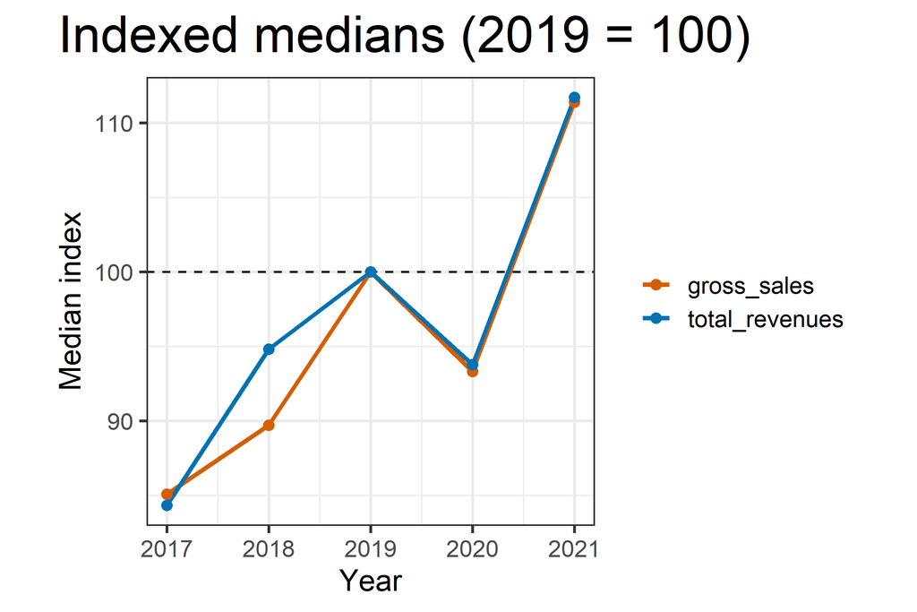

```r
# Median by year & metric with no residual grouping
medyr <- sweden_all |>
  transmute(
    year,
    total_revenues = as.numeric(`Total revenues (data13004)`),
    gross_sales    = as.numeric(`Gross sales (data13000)`)
  ) |>
  pivot_longer(c(total_revenues, gross_sales),
               names_to = "metric", values_to = "value") |>
  group_by(year, metric) |>
  summarise(med = median(value, na.rm = TRUE), .groups = "drop")

# Pulling 2019 baselines per metric
base19 <- medyr |>
  filter(year == 2019) |>
  rename(baseline = med) |>
  select(metric, baseline)

# Joining baseline and computing index (falls back to first non-missing if 2019 is NA/missing)
med_idx <- medyr |>
  left_join(base19, by = "metric") |>
  group_by(metric) |>
  mutate(
    baseline = ifelse(is.na(baseline),
                      med[which.min(abs(year - 2019))],  # fallback baseline
                      baseline),
    idx_2019 = 100 * med / baseline
  ) |>
  ungroup()

ggplot(med_idx, aes(x = year, y = idx_2019, colour = metric)) +
  geom_hline(yintercept = 100, linetype = 2) +
  geom_line(linewidth = 1) +
  geom_point(size = 2) +
  labs(title = "Indexed medians (2019 = 100)",
       y = "Median index", x = "Year", colour = NULL)
```

Gross sales and total revenues move nearly in unison, with a distinct decline in 2020 (~93–94) and a significant rebound in 2021 (~111–112), according to the indexed-median plot (2019 = 100). The dashed line at 100 serves as a marker for changes in relation to the pre-pandemic baseline, and values are based on raw medians with na.rm=TRUE.

We will now compare gross sales to total revenues as a ratio by year to verify consistency between the two metrics. By plotting log10(gross_sales/total_revenues), we may determine if typical firms sit close to equality and how dispersion varies over time. This places “parity” at 0 (i.e., 1×). Thisemploys distributions with modified scales in ggplot2 (Week 5–6).

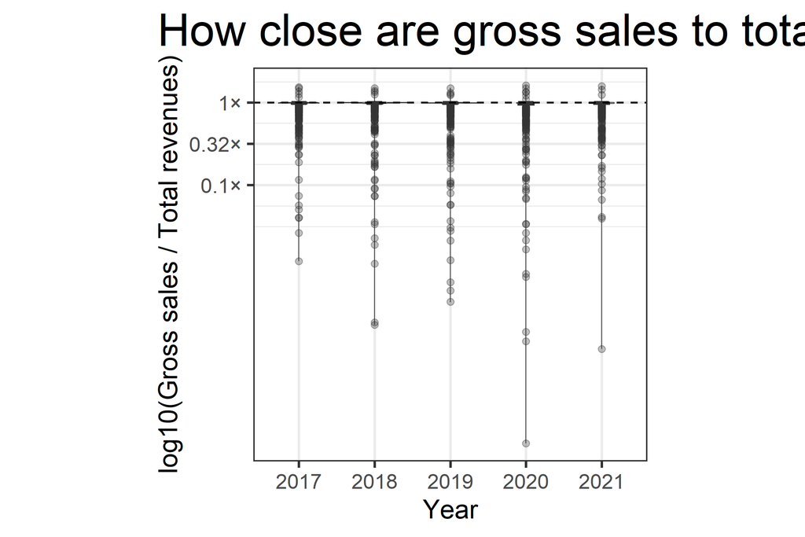

```r
ratio_df <- sweden_all |>
transmute(
year,
total_revenues = as.numeric(`Total revenues (data13004)`),
gross_sales    = as.numeric(`Gross sales (data13000)`)
) |>

# keep comparable values
filter(!is.na(total_revenues), !is.na(gross_sales),
total_revenues > 0, gross_sales >= 0) |>
mutate(
ratio      = gross_sales / total_revenues,
log_ratio  = log10(ratio)           # 0 on this scale ⇔ ratio = 1
)

ggplot(ratio_df, aes(x = factor(year), y = log_ratio)) +
geom_violin(fill = "grey85", linewidth = 0.2, alpha = 0.6, trim = TRUE) +
geom_boxplot(width = 0.2, outlier.alpha = 0.3) +
geom_hline(yintercept = 0, linetype = 2) +
scale_y_continuous(
name = "log10(Gross sales / Total revenues)",
breaks = c(-1, -0.5, 0, 0.5, 1),
labels = c("0.1×","0.32×","1×","3.2×","10×")
) +
labs(
title = "How close are gross sales to total revenues?",
x = "Year"
)
```

# Conclusions

The pandemic caused a brief, moderate revenue shock in 2020, a robust recovery in 2021, increased earnings volatility, and no widespread downsizing, or stress without systemic harm. The remaining concerns which should be considered include survivorship effects, big tails, and zeros/negatives; sector-specific drills and deeper panel models which would improve attribution.

# Resources

The materials used for this report are:

1. Wickham H, Averick M, Bryan J, Chang W, McGowan LD, François R, Grolemund G, Hayes A, Henry L, Hester J, Kuhn M, Pedersen TL, Miller E, Bache SM, Müller K, Ooms J, Robinson D, Seidel DP, Spinu V, Takahashi K, Vaughan D, Wilke C, Woo K, Yutani H (2019). “Welcome to the tidyverse.” *Journal of Open Source Software*, *4*(43), 1686. [doi:10.21105/joss.01686](https://doi.org/10.21105/joss.01686).
2. Bureau van Dijk Electronic Publishing. (n.d.). Osiris. Bureau van Dijk Electronic Publishing. https://ezproxy.lib.monash.edu.au/login?url=http://osiris.bvdep.com/ip
3. Sweden.se. “The Swedish Economy.” Sweden.se, 19 June 2025. Web. Accessed 20 Oct. 2025. https://www.sweden.se/work-business/business-in-sweden/the-swedish-economy
4. OECD. “OECD Economic Surveys: Sweden 2025 – Full Report.” OECD Publishing, 5 June 2025. Web. Accessed 20 Oct. 2025. https://www.oecd.org/en/publications/oecd-economic-surveys-sweden-2025_75e94b2f-en/full-report.html
5. LinkedIn. “Top Companies — Sweden.” LinkedIn, n.d. Web. Accessed [Access on 20 october 2026]. https://www.linkedin.com/hubs/top-companies/se/
6. World Bank. (2022). Chapter 1: The economic impacts of the COVID-19 crisis (in World Development Report 2022). Retrieved October 20, 2025, from https://www.worldbank.org/en/publication/wdr2022/brief/chapter-1-introduction-the-economic-impacts-of-the-covid-19-crisis
7. NordForsk. (2025, August 4). The pandemic: The economy was put in a freezer and the crisis didn’t materialise. NordForsk. https://www.nordforsk.org/news/pandemic-economy-was-put-freezer-and-crisis-didnt-materialise
8. Statista. (n.d.). Number of layoffs after the coronavirus outbreak by industry in Sweden [Statistical table]. Retrieved , from https://www.statista.com/statistics/1110586/number-of-layoffs-after-the-coronavirus-outbreak-by-industry-in-sweden/?srsltid=AfmBOoqZPfe6Toecil3_IHAd7HBKkwSdgG5PsI-5CTRtkTR_nnzaypCL
9. Zhu H. (n.d.). kableExtra: Construct Complex Table with ‘kable’ and Pipe Syntax. R package. Retrieved from https://CRAN.R-project.org/package=kableExtra.
10. Waring E., Quinn M., McNamara A., et al. (n.d.). skimr: Compact and Flexible Summaries of Data Frames. R package. Retrieved from https://CRAN.R-project.org/package=skimr.